# STAT 360: Computational Statistics and Data Analysis

### Load Relevant R Libraries

```r
library(rmarkdown); library(knitr); library(readxl)
library(moments); library(corrplot); library(pso)
library(psych); library(GPArotation); library(lavaan)
```

### EXERCISE 01

#### Part (a)

```r
asc<-c(1,4,6,7)
asc
```

```
## [1] 1 4 6 7
```

```r
dec<-c(7,6,4,1)
dec
```

```
## [1] 7 6 4 1
```

```r
# Insert code or written answer here
```

#### Part (b)

```r
meanasc<-(1+4+6+7)/4
meanasc
```

```
## [1] 4.5
```

```r
sdasc<-(((1-4.5)^2+(4-4.5)^2+(6-4.5)^2+(7-4.5)^2)/(4-1))^(1/2)
sdasc
```

```
## [1] 2.645751
```

```r
sddec<-(((7-4.5)^2+(6-4.5)^2+(4-4.5)^2+(1-4.5)^2)/(4-1))^(1/2)
sddec
```

```
## [1] 2.645751
```

```r
# Insert code or written answer here
```

#### Part (c)

```r
sp <- ((1-4.5)*(7-4.5))+((4-4.5)*(6-4.5))+((6-4.5)*(4-4.5))+((7-4.5)*(1-4.5))
sp
```

```
## [1] -19
```

```r
cov<- sp/(4-1)
cov
```

```
## [1] -6.333333
```

```r
# Insert code or written answer here
```

#### Part (d)

```r
cor<-cov/(sdasc*sddec)
cor
```

```
## [1] -0.9047619
```

```r
# Insert code or written answer here
```

### EXERCISE 02

#### Part (a)

```r
data<- data.frame(Candidate=c("Elsenhover","Johnson","Nixon","Ford", "Carter","Reagan","BushSr","Clinton","BrushJr","Obama","Trump"),Year =c(1956,1964,1972,1976,1980, 1984, 1992,1996,2004,2012,2020),Approval=c(68,74,59,45,37,58,35,54,48,52,45),Margin=c(15.4,22.6,23.2,-2.1,-0.7,18.2,-5.5,8.5,2.4,3.9,-4.4))
data
```

```
##     Candidate Year Approval Margin
## 1  Elsenhover 1956       68   15.4
## 2     Johnson 1964       74   22.6
## 3       Nixon 1972       59   23.2
## 4        Ford 1976       45   -2.1
## 5      Carter 1980       37   -0.7
## 6      Reagan 1984       58   18.2
## 7      BushSr 1992       35   -5.5
## 8     Clinton 1996       54    8.5
## 9     BrushJr 2004       48    2.4
## 10      Obama 2012       52    3.9
## 11      Trump 2020       45   -4.4
```

```r
# Insert code or written answer here
```

#### Part (b)

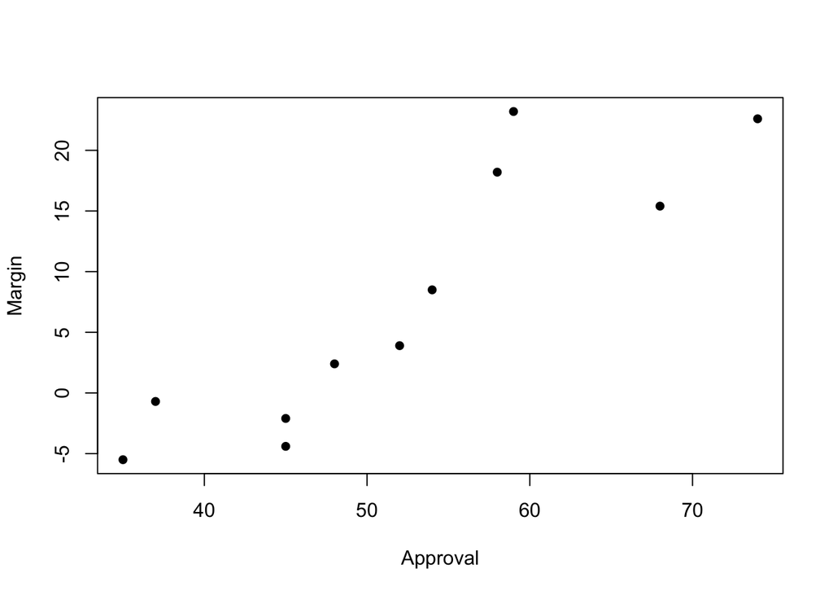

```r
plot(data[,3],data[,4],pch=16, xlab = "Approval",ylab ="Margin")
```

```r
# Insert code or written answer here
```

#### Part (c)

The association appears to be positive, linear and strong.

#### Part (d)

```r
cor(data[,3],data[,4])
```

```
## [1] 0.8842433
```

```r
# Insert code or written answer here
```

### EXERCISE 03

#### Part (a)

```r
IsleRoyale <- matrix(c(20, 538, NA, NA, 20,
         22, 564, NA, NA, 14.3,
         22, 572, NA, NA, 19.5,
         23, 579, NA, NA, 16.5,
         20, 596, NA, NA, 21.2,
         26, 620, NA, NA, 15.9,
         28, 634, NA, NA, 13.2,
         26, 661, NA, NA, 18,
         22, 766, NA, NA, 21,
         22, 848, NA, NA, 20,
         17, 1041, NA, NA, 16.5,
         18, 1045, NA, NA, 16.1,
         20, 1183, 0.615, 0.062, 11.4,
         23, 1243, 0.819, 0.091, 10.7,
         24, 1215, 0.760, 0.090, 15.1,
         31, 1203, 0.599, 0.093, 14.7,
         41, 1139, 0.645, 0.139, 12.3,
         44, 1070, 0.563, 0.139, 10.3,
         34, 949, 0.298, 0.064, 6.1,
         40, 845, 0.507, 0.144, 10.2,
         43, 857, 0.387, 0.117, 13,
         50, 788, 0.330, 0.126, 12,
         30, 767, 0.217, 0.051, 23.7,
         14, 780, 0.869, 0.094, 20.7,
         23, 830, 0.394, 0.065, 16.4,
         24, 927, 0.440, 0.068, 14.5,
         22, 976, 0.457, 0.062, 13.1,
         20, 1014, 0.670, 0.079, 16,
         16, 1046, 0.549, 0.050, 16,
         12, 1116, 0.864, 0.056, 15.2,
         12, 1260, 0.810, 0.046, 13.4,
         15, 1315, 0.857, 0.059, 14.8,
         12, 1496, 1.029, 0.050, 13.9,
         12, 1697, 1.428, 0.061, 10.9,
         13, 1784, 0.877, 0.038, 14,
         17, 2017, 0.792, 0.040, 12,
         16, 2117, 1.391, 0.063, 7,
         22, 2398, 1.274, 0.070, 3), nrow = 38, ncol = 5, byrow = T,
       dimnames = list(c("1959", "1960", "1961","1962","1963","1964","1965","1966","1967","1968","1969", "1970", "1971","1972","1973","1974","1975","1976","1977","1978","1979","1980","1981","1982","1983","1984","1985","1986","1987","1988","1989","1990","1991","1992","1993","1994","1995","1996"),
                       c("Wolves", "Moose", "Kill Rate", "Predation Rate", "Moose Recruitment Rate")))
IsleRoyale
```

```
##      Wolves Moose Kill Rate Predation Rate Moose Recruitment Rate
## 1959     20   538        NA             NA                   20.0
## 1960     22   564        NA             NA                   14.3
## 1961     22   572        NA             NA                   19.5
## 1962     23   579        NA             NA                   16.5
## 1963     20   596        NA             NA                   21.2
## 1964     26   620        NA             NA                   15.9
## 1965     28   634        NA             NA                   13.2
## 1966     26   661        NA             NA                   18.0
## 1967     22   766        NA             NA                   21.0
## 1968     22   848        NA             NA                   20.0
## 1969     17  1041        NA             NA                   16.5
## 1970     18  1045        NA             NA                   16.1
## 1971     20  1183     0.615          0.062                   11.4
## 1972     23  1243     0.819          0.091                   10.7
```

[output cut: 24 more lines]

```r
# Insert code or written answer here
```

```r
mean(IsleRoyale[,1])
```

```
## [1] 23.57895
```

```r
mean(IsleRoyale[,2])
```

```
## [1] 1065.684
```

#### Part (b)

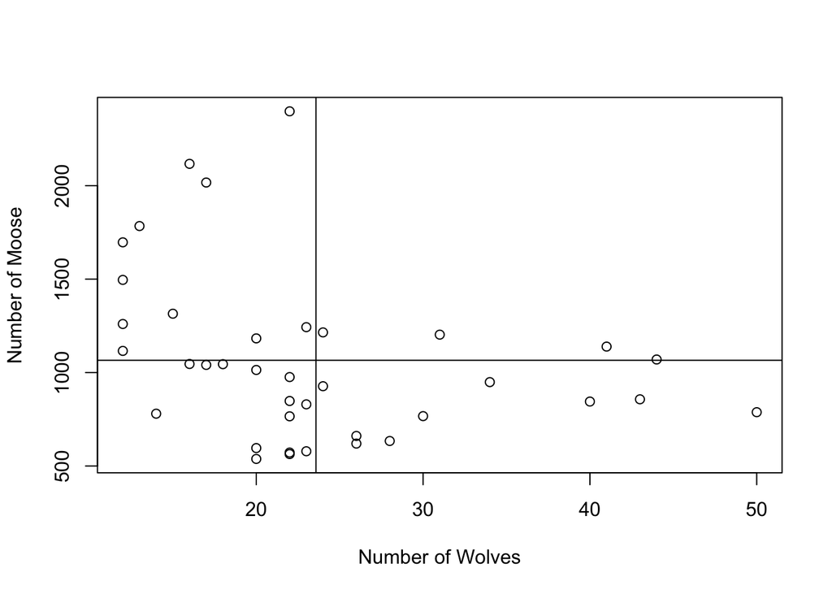

```r
plot(IsleRoyale[,1],IsleRoyale[,2], xlab = "Number of Wolves",ylab = "Number of Moose")
abline(v=mean(IsleRoyale[,1]),h = mean(IsleRoyale[,2]))
```

```r
# Insert code or written answer here
```

#### Part (c)

Looking at the scatter plot and the quadrants, it is clear that there is more data point on the left upper quadrant and right bottom quadrant, when compared to the right upper quadrant and left bottom quadrant. This means that the covariability is likely to be negative.

#### Part (d)

```r
a<-cov(IsleRoyale[,1],IsleRoyale[,2])
a
```

```
## [1] -1393.92
```

```r
b<-cor(IsleRoyale[,1],IsleRoyale[,2])
b
```

```
## [1] -0.3236099
```

```r
# Insert code or written answer here
```

#### Part (e)

Both the covariance and correlation are negative.

### Part (f)

Since the correlation is -0.32 and -1 means strong correlation, this is moderate covariability.

### EXERCISE 04

#### Part (a)

```r
Anscombe<- matrix(c(10.0, 8.04, 10.0, 9.14, 10.0, 7.46, 8.0, 6.58,
                            8.0, 6.95, 8.0, 8.14, 8.0, 6.77, 8.0, 5.76,
                            13.0, 7.58, 13.0, 8.74, 13.0, 12.74, 8.0, 7.71,
                            9.0, 8.81, 9.0, 8.77, 9.0, 7.11, 8.0, 8.84,
                            11.0, 8.33, 11.0, 9.26, 11.0, 7.81, 8.0, 8.47,
                            14.0, 9.96, 14.0, 8.10, 14.0, 8.84, 8.0, 7.04,
                            6.0, 7.24, 6.0, 6.13, 6.0, 6.08, 8.0, 5.25,
                            4.0, 4.26, 4.0, 3.10, 4.0, 5.39, 19.0, 12.50,
                            12.0, 10.84, 12.0, 9.13, 12.0, 8.15, 8.0, 5.56,
                            7.0, 4.82, 7.0, 7.26, 7.0, 6.42, 8.0, 7.91,
                            5.0, 5.68, 5.0, 4.74, 5.0, 5.73, 8.0, 6.89), nrow = 11, ncol = 8, byrow = T, dimnames = list (c("1", "2", "3", "4", "5", "6", "7", "8", "9", "10", "11"), c("X1", "Y1", "X2", "Y2", "X3", "Y3", "X4", "Y4")))
Anscombe
```

```
##    X1    Y1 X2   Y2 X3    Y3 X4    Y4
## 1  10  8.04 10 9.14 10  7.46  8  6.58
## 2   8  6.95  8 8.14  8  6.77  8  5.76
## 3  13  7.58 13 8.74 13 12.74  8  7.71
## 4   9  8.81  9 8.77  9  7.11  8  8.84
## 5  11  8.33 11 9.26 11  7.81  8  8.47
## 6  14  9.96 14 8.10 14  8.84  8  7.04
## 7   6  7.24  6 6.13  6  6.08  8  5.25
## 8   4  4.26  4 3.10  4  5.39 19 12.50
## 9  12 10.84 12 9.13 12  8.15  8  5.56
## 10  7  4.82  7 7.26  7  6.42  8  7.91
## 11  5  5.68  5 4.74  5  5.73  8  6.89
```

```r
# Insert code or written answer here
```

#### Part (b)

```r
a1<-cov(Anscombe[,1],Anscombe[,2])
a1
```

```
## [1] 5.501
```

```r
a2<-cov(Anscombe[,3],Anscombe[,4])
a2
```

```
## [1] 5.5
```

```r
a3<-cov(Anscombe[,5],Anscombe[,6])
a3
```

```
## [1] 5.497
```

```r
a4<-cov(Anscombe[,7],Anscombe[,8])
a4
```

```
## [1] 5.499
```

```r
# Insert code or written answer here
```

#### Part (c)

```r
a1<-cor(Anscombe[,1],Anscombe[,2])
a1
```

```
## [1] 0.8164205
```

```r
a2<-cor(Anscombe[,3],Anscombe[,4])
a2
```

```
## [1] 0.8162365
```

```r
a3<-cor(Anscombe[,5],Anscombe[,6])
a3
```

```
## [1] 0.8162867
```

```r
a4<-cor(Anscombe[,7],Anscombe[,8])
a4
```

```
## [1] 0.8165214
```

```r
# Insert code or written answer here
```

#### Part (e)

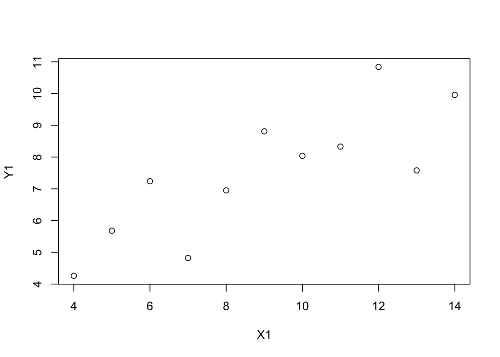

```r
plot(Anscombe[,1],Anscombe[,2], xlab = "X1",ylab = "Y1")
```

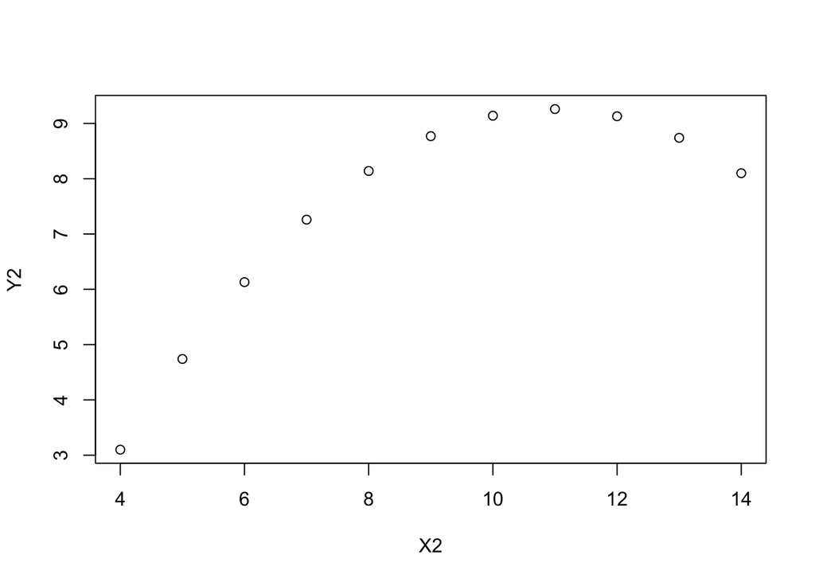

```r
plot(Anscombe[,3],Anscombe[,4], xlab = "X2",ylab = "Y2")
```

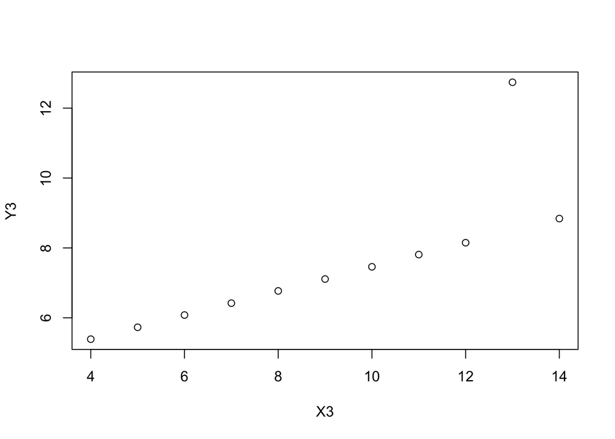

```r
plot(Anscombe[,5],Anscombe[,6], xlab = "X3",ylab = "Y3")
```

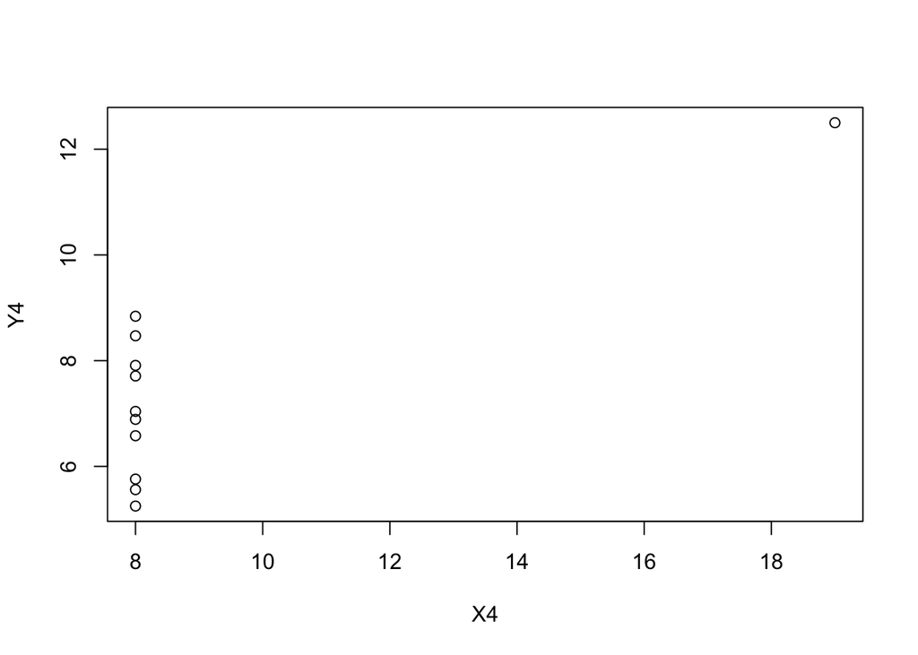

```r
plot(Anscombe[,7],Anscombe[,8], xlab = "X4",ylab = "Y4")
```

```r
# Insert code or written answer here
```

#### Part (f)

We can see that even though the value of covaribility was approximately the same for the four quartets, the graphs for all of them are totally different. The first one is a simple linear relationship, second one is like an inverted U shape, third one is linear but is off by an oulier, and fourth is parallel to y axis along with a significant outlier. This emphasizes on the importance of data visualization for statistical analysis and proves why we cannot just depend on summary statistics to derive conclusions.